# final project

team 2

2025-05-15

```r
library(e1071)
```

```r
library(ggplot2)
library(nortest)
library(rattle)
library(ggpubr)
library(goftest)
library(fitdistrplus)
```

The data contains information about chocolate sales such as: sales person, country, the product sold, date, sold amount in USD and the number of shipped boxes.

```r
chocolate_data = read.csv(file="DataSets\\chocolate_sales.csv")
summary(chocolate_data)
```

```
##  Sales.Person         Country            Product              Date
##  Length:1094        Length:1094        Length:1094        Length:1094
##  Class :character   Class :character   Class :character   Class :character
##  Mode  :character   Mode  :character   Mode  :character   Mode  :character
##
##
##
##     Amount          Boxes.Shipped
##  Length:1094        Min.   :  1.0
##  Class :character   1st Qu.: 70.0
##  Mode  :character   Median :135.0
##                     Mean   :161.8
##                     3rd Qu.:228.8
##                     Max.   :709.0
```

We will analyze the number of shipped boxes per sale.

TESTING PROBLEM: finding the appropriate distribution for our data

```r
boxes = na.omit(chocolate_data$Boxes.Shipped)
```

Firstly, we want to check if the data follows a normal distribution.

Descriptive statistics:

```r
summary(boxes)
```

```
##    Min. 1st Qu.  Median    Mean 3rd Qu.    Max.
##     1.0    70.0   135.0   161.8   228.8   709.0
```

```r
skewness(boxes)
```

```
## [1] 1.109529
```

```r
kurtosis(boxes)
```

```
## [1] 1.14608
```

Skewness and kurtosis are positive so the data is right-skewed and leptokurtic. It has heavier tails and a sharper peak compared to the normal distribution.

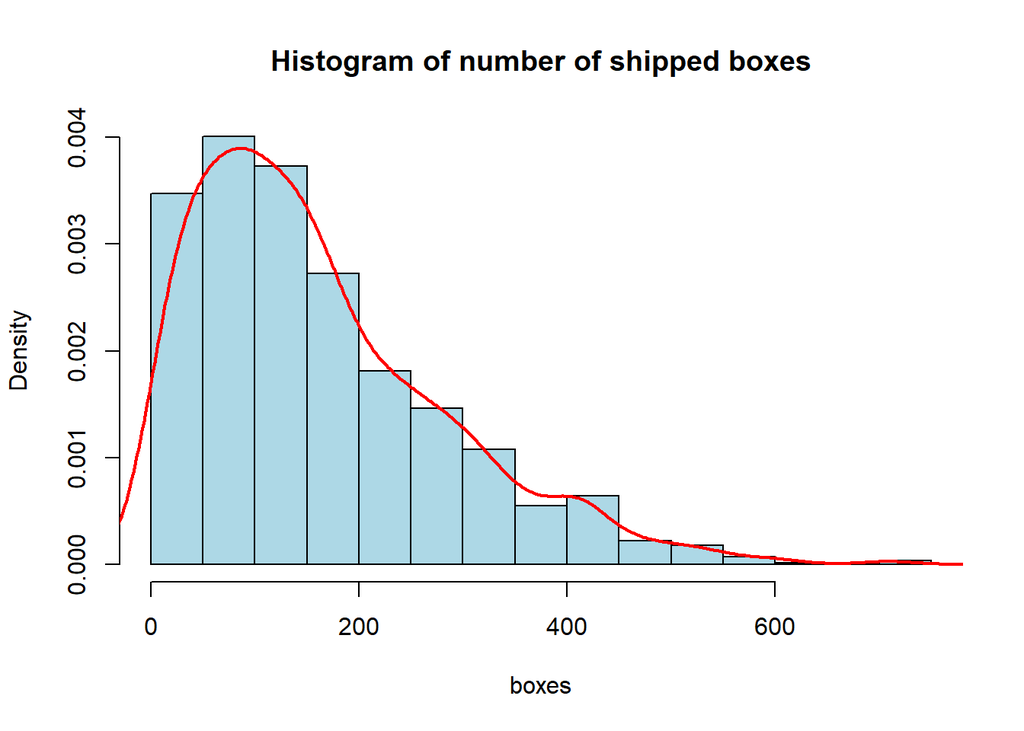

```r
hist(boxes, main='Histogram of number of shipped boxes', col='lightblue', probability = TRUE)
lines(density(boxes), col='red', lwd=2)
```

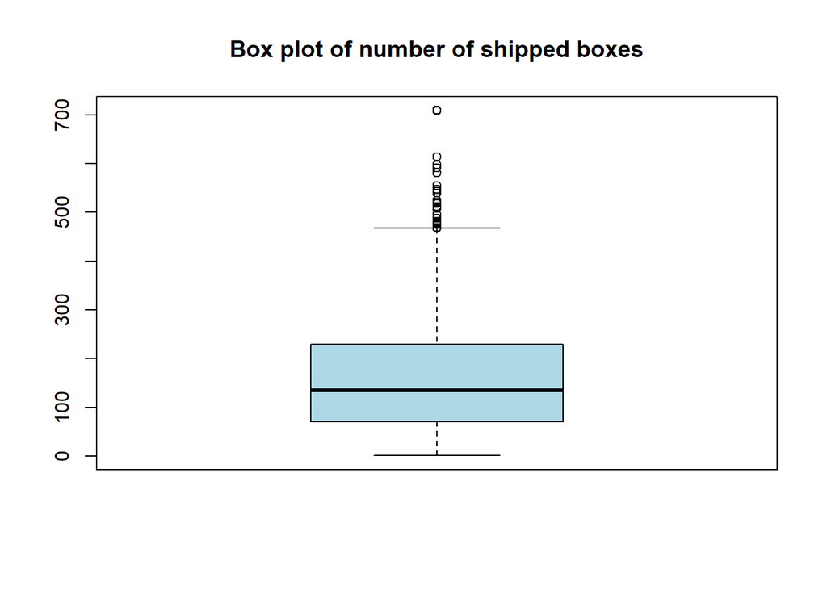

```r
boxplot(boxes, main='Box plot of number of shipped boxes', col='lightblue')
```

```r
median(boxes)
```

```
## [1] 135
```

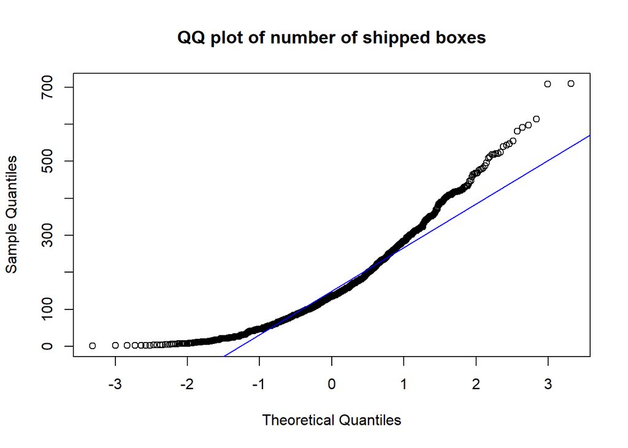

```r
qqnorm(boxes, main='QQ plot of number of shipped boxes')
qqline(boxes, col="blue")
```

The QQ plot is U-shaped and the tails are above the reference line. This indicated that the normal distribution is not capturing tail behavior correctly (our data has heavier tails).

Tests for normality

```r
# Shapiro-Wilk test
shapiro.test(boxes)
```

```
##
##  Shapiro-Wilk normality test
##
## data:  boxes
## W = 0.91562, p-value < 2.2e-16
```

The p-value is very small so we can reject the null hypothesis. The data doesn’t follow a normal distribution.

```r
# Anderson-Darling test
ad.test(boxes)
```

```
##
##  Anderson-Darling test of goodness-of-fit
##  Null hypothesis: uniform distribution
##  Parameters assumed to be fixed
##
## data:  boxes
## An = Inf, p-value = 5.484e-07
```

Now we want to find the appropriate distribution for our data.

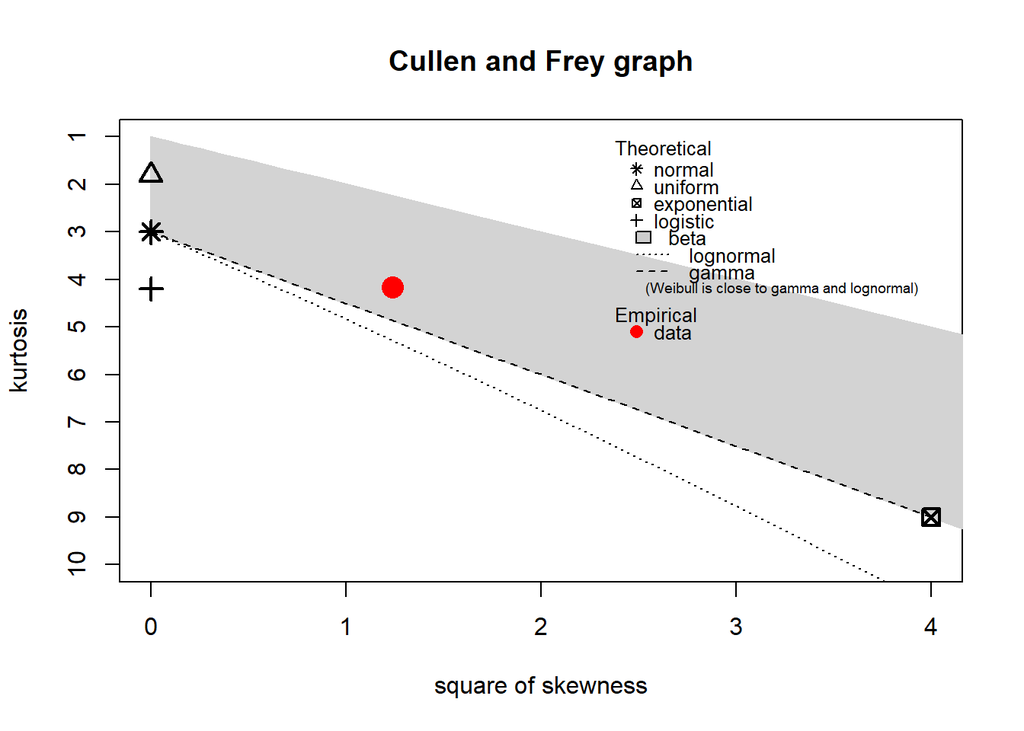

```
## summary statistics
## ------
## min:  1   max:  709
## median:  135
## mean:  161.798
## estimated sd:  121.5441
## estimated skewness:  1.112578
## estimated kurtosis:  4.164465
```

```r
descdist(boxes)
```

Based on the Cullen and Frey graph we want to test the fit of lognormal distribution and gamma distribution.

Lognormal

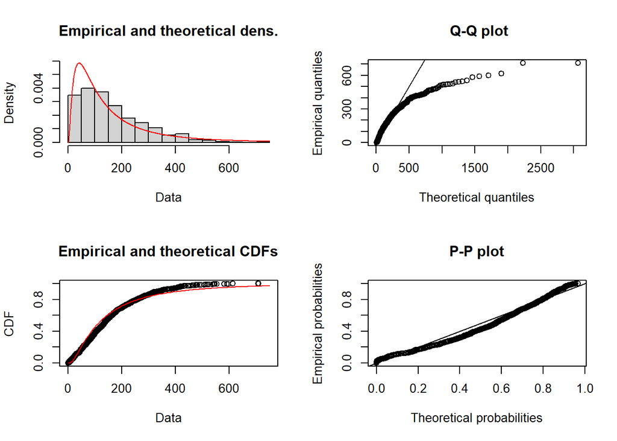

```r
fit_lnorm = fitdist(boxes, 'lnorm')
plot(fit_lnorm)
```

Gamma

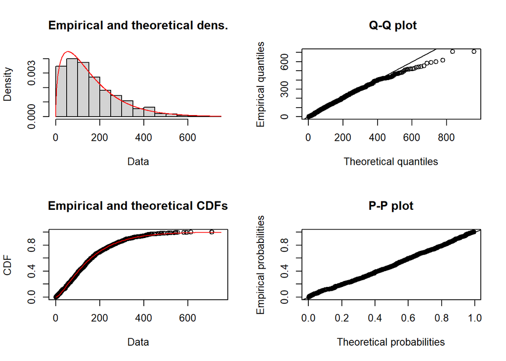

```r
fit_gamma = fitdist(boxes, 'gamma')
plot(fit_gamma)
```

```r
gofstat(list(fit_lnorm, fit_gamma))
```

```
## Goodness-of-fit statistics
##                              1-mle-lnorm 2-mle-gamma
## Kolmogorov-Smirnov statistic  0.08697216  0.03330313
## Cramer-von Mises statistic    2.82178112  0.24782253
## Anderson-Darling statistic   17.63694960  1.67807956
##
## Goodness-of-fit criteria
##                                1-mle-lnorm 2-mle-gamma
## Akaike's Information Criterion    13434.80    13218.08
## Bayesian Information Criterion    13444.79    13228.07
```

All goodness-of-fit statistics are significantly lower for the gamma distribution, indicating a closer match.

Kolmogorov-Smirnov: The gamma Cumulative Distribution Function is closer to our data’s Empirical Distribution Function than the log-normal’s.

Cramer-von Mises: The gamma distribution more closely follows the shape of our data’s distribution.

Anderson-Darling: Gamma captures the tail behavior of our data far better than the log-normal distribution, which has heavy mismatches in the tails.

The AIC and BIC values, which account for model complexity, are also lower for the gamma distribution, meaning it fits our data much better.

We conclude that the data is well-modeled by the gamma distribution.